# Tarea 4 Evaluación Integración

## 1. Difracción de una onda plana

**Sea $\lambda$ una onda plana que es bloqueada por un objeto con un borde, ver Figura 1**

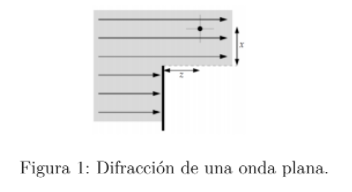

**La onda sera difractada por el borde y la intensidad resultante en la posición (x, z) marcada por el punto esta dada por la teoría de difracción de campo cercano**

$$I = \dfrac{I}{8} \left( [2C(u) + 1]^2 + [2S(u)+1]^2 \right) $$

**Donde $I_0$ es la intensidad de la función de onda antes de la difracción, mientras que**

$$ u = x \sqrt{\dfrac{2}{\lambda z}} \;\; ,\;\; C(u) = \int_0^u \cos \dfrac{1}{2} \pi t^2 dt \;\; , \;\; S(u) = \int_0^u \sin \dfrac{1}{2} \pi t^2 dt$$

**(i) Escribe un programa que calcule $I/I_0$**

```python
# Importamos las librerias que necesitaremos
import numpy as np
import matplotlib.pyplot as plt
```

Primero definimos una funcion $f_u$ que nos da u a partir de x

Y también una función IentreI0 que nos da I/I0 si ya conocemos C y S

```python
# Definimos las funciones según la definición dada en el enunciado
def f_u(lamb,z,x):
    return(x*np.sqrt(2/(lamb*z)))

def IentreI0(C,S):
    res = 1/8 * ((2*C+1)**2+(2*S+1)**2)
    return(res)
```

**(ii)Gráfica la intensidad resultante I para 3 distintas Io, en un intervalo x= [−5, 5] metros; supón el caso de una onda de sonido (λ = 1, y z = 3m). Calcula las integrales con el método de Simpson.**

Definimos una función que calcula la integral de f desde a hasta b con N intervalos usando el método de Simpson. Según dicho método, podemos calcular la integral como sigue:

[figure not shown]

Donde $h = (b-a)/N$

```python
# La función toma como entrada f, los límites a,b y la cantidad de divisiones N

def simp(f,a,b,N=2000):
    # calculamos h según la def
    h = (b-a)/N

    # Hacemos un conjunto de valores de x desde a hasta b, en los que evaluaremos f
    x = np.linspace(a,b,N+1)
    # Evaluamos f en todos estos puntos
    y = f(x)

    #calculamos el resultado según la fórmula.
    # Necesitamos sumar sobre los impares (la suma de y[1::2])
    # y sobre los pares y[0:N-1:2]
    res = h/3 * (f(a)+f(b)+4*np.sum(y[1::2])+2*np.sum(y[0:N-1:2]))
    return(res)
```

Definimos ahora las funciones C(u) y S(u)

```python
# Ammbas se calculan como integrales, así que usamos nuestra función simp
# para integrar desde 0 hasta u
# El integrando lo definimos ahí mismo usando la lambda
def f_C(u):
    return(simp(lambda t: np.cos(np.pi*t**2/2),0,u))
def f_S(u):
    return(simp(lambda t: np.sin(np.pi*t**2/2),0,u))
```

En esta celda graficamos la intensidad I para 3 valores distintos de $I_0$ y usando lambda = 1 y z = 3m

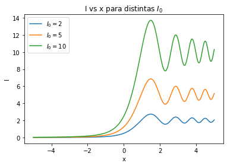

```python
# Definimos z y lambda
z= 3
lamb = 1


# Creamos los valores de x en el intervalo -5 a 5
xp = np.linspace(-5,5,500)
# A partir de esos valores de x, calculamos primero
# los puntos up que usaremos usando la función f_u
up = f_u(lamb,z,xp)


# Vamos a graficar primero para una intensidad I0 = 2
I0 =2
# Creamos una lista vacía donde guardaremos nuestros resultados
I = []
# Vamos iterando sobre los valores de u en la lista up
for u in up:
    # para cada u, le calculamos las dos integrales usando las funcioes f_C y f_S
    C = f_C(u)
    S = f_S(u)
    # a la lista I agragamos el resultado de la intensidad para esta u
    # Para ello usamos la funcion IentreI0 y la multiplicamos por I0
    I.append(I0*IentreI0(C,S))
# graficamos
plt.plot(xp,I,label=r'$I_0 = 2$')



# Hacmos todo igual para otra intensidad (I0 = 5)
I0 =5
I = []
for u in up:
    C = f_C(u)
    S = f_S(u)
    I.append(I0*IentreI0(C,S))
plt.plot(xp,I,label=r'$I_0 = 5$')


# Y finalmente para I0 = 10
I0 =10
I = []
for u in up:
    C = f_C(u)
    S = f_S(u)
    I.append(I0*IentreI0(C,S))
plt.plot(xp,I,label=r'$I_0 = 10$')


# Le damos nombres a los ejes y título a las gráficas
plt.xlabel("x")
plt.ylabel('I')
plt.title('I vs x para distintas $I_0$')
plt.legend()
```

##### (iii) Análisis

Vemos que las tres gráficas se comportan de forma muy similar, sólo que con distintas intensidades.

Las graficas empiezan teniendo un valor muy cercano al 0 para x negativo, lo cual tiene sentido, pues como se ve en la imagen del problema, esta es la zona en la que la pared detiene a las ondas.

Luego, para x poisitvo, la intensidad empieza a crecer y luego oscila creando un patrón de interferencia. Vemos que conforme aumenta x, la intensidad I tiende hacia I0 en cada uno de los casos. Esto es de esperar, pues para x grande nos encontramos muy lejos de la pared mostrada en la imagen del problema, por lo que es como si la onda se propagara sin obstáculos y siguiera con su intensidad normal

## 2. Periodo de un Péndulo

El periodo de un péndulo simple de longitud $L$ es

$$ \tau = 4h (\theta_0) \sqrt{\dfrac{L}{g}}$$

Donde $g$ es el valor de la gravedad, $\theta_0$ representa la amplitud angular y

$$ h(\theta_0) = \int_0^{\pi/2} \dfrac{d\theta}{\sqrt{1-\sin^2 \left( \dfrac{\theta_0}{2} \right) \sin^2 (\theta)}}$$

**(i) Calcula el periodo de oscilación para diferentes ángulos $\theta_0 = \pi/12 , \pi/6, \pi/4$**

Definimos la funcion h, que se calcula como una integral

```python
# h toma el valor th0 (theta cero) y a partir de eso nos da un resultado según la integral
def h(th0):
    #primero definimos el integrando en la variable th usando una función lambda
    func = lambda th: 1/np.sqrt(1-(np.sin(th0/2))**2*(np.sin(th))**2)
    # res es el resultado de la integral, que calculamos usando simpson
    res = simp(func, 0, np.pi/2)
    return(res)

#Esta función calcula el periodo de la oscilación
#toma como entrada el th0 y L (predeterminado a 10)
def periodo(th0,L=10):
    # Calcula el valor de h correspondiente y luego usa la def. de tau
    tau = 4*h(th0)*np.sqrt(L/9.81)
    return(tau)

# Calculamos el periodo para distintos ángulos
print('Periodo para pi/12: ' , periodo(np.pi/12,10))
print('Periodo para pi/6: ' ,periodo(np.pi/6,10))
print('Periodo para pi/4: ' ,periodo(np.pi/4,10))
```

```
Periodo para pi/12:  6.373136184646588
Periodo para pi/6:  6.456291312205615
Periodo para pi/4:  6.599434919313243
```

**(ii) Grafica $\theta_0$ vs $\tau$. Asegúrate que la gráfica tenga 200 puntos y que los valores de $ \theta_0$ estén en el intervalo $[0, \pi/4]$**

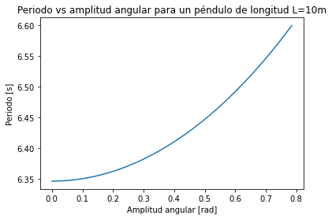

```python
# creamos 200 puntos en este intervalo
th0p = np.linspace(0,np.pi/4,200)

# Hacemos una lista vacía para guardar los resultados de los periodod
taup=[]


# vamos iterando sobre las thetas 0
# y agregamos el periodo correspondiente a la lista de periodos
for th0 in th0p:
    taup.append(periodo(th0))

# graficamos
plt.plot(th0p,taup)
plt.title('Periodo vs amplitud angular para un péndulo de longitud L=10m')
plt.ylabel('Periodo [s]')
plt.xlabel('Amplitud angular [rad]')
```

**iii) Comenta con tus propias palabras los resultados de la gráfica.**

Vemos que para ángulos chiquitos, el periodo es muy cercano a 6.34.

Esto coincide con la aproximación usual para ángulos chiquitos que se suele hacer, la que dice que el periodo es $T = 2\pi \sqrt{\dfrac{L}{g}}$, que en este caso, usando $L = 10$, $g = 9.81$ tiene un valor de:

```python
T = 2*np.pi*np.sqrt(10/9.81)
print(T)
```

```
6.343739849219413
```

Entonces, nuestra gráfica tiene un comportamiento para ángulos chiquitos que coincide con esta aproximación, lo que justifica el uso de la aproximación cuando el ángulo es lo suficientemente pequeño.

Sin embargo, vemos que conforme aumenta la amplitud angular, el periodo también aumenta, aunque no llega a aumentar muy significativamente incluso para ángulos de casi 0.8 radianes, valor para el cual el periodo alcanza un valor de 6.6s